# LAB3

Chi Sun

2023-11-09

## Library Import and Data Loading

This section imports necessary R libraries for data processing and visualization. It then loads the `MichiganFlickr.csv` file into a data frame named MichFlickr. This dataset is assumed to contain information about photographs uploaded to Flickr from Michigan.

```r
library(readr)
library(ggplot2)
library(ggthemes)
library(gganimate)
library(foreign)
library(dplyr)
library(rnaturalearth)
library(rnaturalearthdata)
library(gifski)
library(lubridate)
library(wesanderson)
library(sf)

MichFlickr <- read.csv("MichiganFlickr.csv")
```

## Generate a Universal Date

This chunk converts the ‘dateupload’ field from the MichFlickr dataset to a more standard Date format. It also extracts and stores year, month, and day as separate columns. Additionally, a count column is initialized to 1 for each record, which could be used later in aggregating data.

```r
MichFlickr$date <- as.POSIXct(MichFlickr$dateupload, origin="1970-01-01")
MichFlickr$date <- as.Date(format(MichFlickr$date, format="%Y-%m-%d"))
MichFlickr$year <- year(MichFlickr$date)
MichFlickr$month <- month(MichFlickr$date, label = TRUE)
MichFlickr$day <- day(MichFlickr$date)
MichFlickr$count<- 1
```

## Daily Photography Analysis

This code block is dedicated to analyzing the daily photography trends in the dataset. It groups the data by the date and calculates the total number of photos taken each day. This provides insight into the daily volume of photography activity in Michigan as captured by Flickr.

```r
daily_photography <- MichFlickr %>%
  mutate(day = as.Date(date, format="%Y-%m-%d")) %>%
  group_by(date) %>% # group by the day column
  summarise(total_photos=sum(count)) %>%  # calculate the SUM of all precipitation that occurred on each day
  na.omit()
```

## Monthly Photography Analysis and Geospatial Visualization

```r
library(maps)
library(classInt)
# Ensure to define the date range first
min <- as.Date("2017-01-01")
max <- as.Date("2017-12-01")

# Filter the data using the defined date range
Filtered_data <- MichFlickr %>%
  filter(date >= min & date <= max)

# Retain the required columns
MichFlickr_filtered <- Filtered_data %>%
  select(id, owner, date, year, month, day, count, latitude, longitude, Landuse)

# Create a dataset grouped by month using the filtered dataset
monthly_photography <- MichFlickr_filtered %>%
  filter(!is.na(latitude) & !is.na(longitude)) %>% # Filter out NA values for latitude and longitude
  group_by(date, latitude, longitude, Landuse) %>%
  summarise(total_photos = sum(count)) %>%
  na.omit()

# Categorical variable
monthly_photography$photo_cat <- cut(monthly_photography$total_photos, breaks = c(0, 1, 2, 5, 10, 20, 50, Inf), labels = c("0-1", "1-2", "2-5", "5-10", "10-20", "20-50", ">50"))

usa_counties_map <- map_data("county")
michigan_counties_map <- usa_counties_map %>%
  filter(region == "michigan")

# Create a dynamic map
p_monthly_map <- ggplot() +
  geom_polygon(data = michigan_counties_map, aes(x = long, y = lat, group = group), fill = "lightgrey", color = "white") +
  geom_point(data = monthly_photography, aes(x = longitude, y = latitude, color = as.factor(photo_cat), size = total_photos), alpha = 0.5) +
  scale_color_manual(values = c("0-1" = "blue", "1-2" = "lightblue", "2-5" = "green", "5-10" = "lightgreen", "10-20" = "yellow", "20-50" = "red", ">50" = "darkred")) +
  scale_size(range = c(8, 60)) +
  theme_minimal() +
  theme(
    axis.text.x = element_text(size = 25),  # Set font size for the x-axis
    axis.text.y = element_text(size = 25)   # Set font size for the y-axis
  ) +
  theme(legend.position = "bottom") +
  labs(title = 'Michigan Photo Hotspot by Flickr', x = 'Longitude', y = 'Latitude', color = 'Total Photos', size = 'Total Photos')

# Create a dynamic map using gganimate
anim_monthly_map <- p_monthly_map +
  transition_time(date) +  # Use the date field as the basis for the animation
  ease_aes('linear') +
  labs(title = 'Michigan Photo Hotspot by Flickr: {frame_time}', x = 'Longitude', y = 'Latitude', color = 'Total Photos', size = 25)

# Save the dynamic map
# Set the nframes parameter to 30 to make the animation approximately 3 seconds long
anim_save("monthly_tourism_over_time.gif", animation = anim_monthly_map, width = 1600, height = 1600, nframes = 30)
```

## User Photo Distribution Analysis

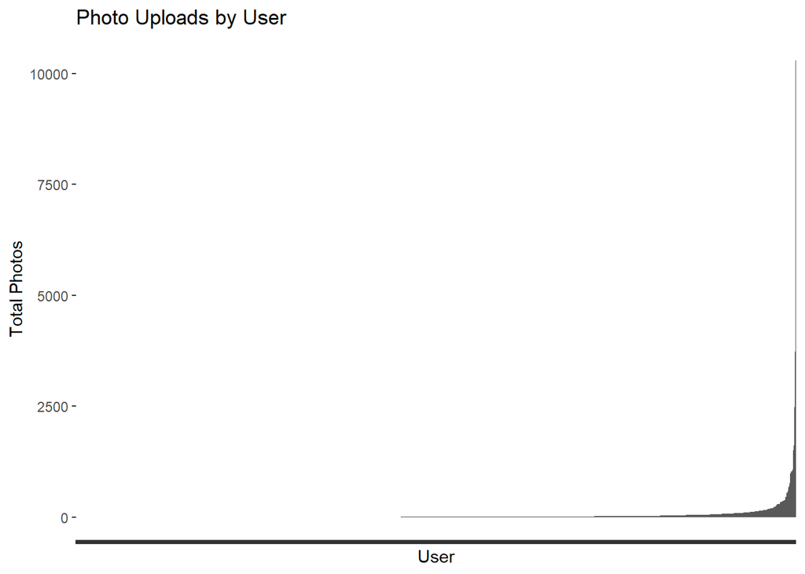

```r
# Calculate the number of photos uploaded by each user
user_photo_count <- MichFlickr_filtered %>%
  group_by(owner) %>%
  summarise(total_photos = n()) %>%
  arrange(desc(total_photos))

# Plotting the distribution of photo uploads by each user
ggplot(user_photo_count, aes(x = reorder(owner, total_photos), y = total_photos)) +
  geom_bar(stat = "identity") +
  theme(axis.text.x = element_blank()) +
  labs(title = "Photo Uploads by User", x = "User", y = "Total Photos")
```

## Implementing a Dynamic Weighting System

To dynamically adjust the weight based on the number of photos uploaded by each user, we can design a sliding scale weight system. This system will decrease the weight of each photo as the number of photos uploaded by a user increases relative to a certain baseline value. Thus, the more photos a user uploads, the smaller the impact of each of their photos on the total daily photo count.

Steps to Implement the Weighting System - Determine Baseline Value and Weight Function:

- Establish a baseline value, such as the median or average number of photos uploaded by all users. Design a weight function that reduces the weight as the number of uploads exceeds the baseline value. Calculate Weight for Each User:
- For each user, calculate the weight based on their upload count and the weight function. Apply Weights to Dataset:
- Adjust the count value for each record in the dataset based on the weight of its user. Recalculate Total Daily Photo Counts:
- Using the adjusted data, recalculate the total number of photos for each day.

```r
# Calculate the median number of photos uploaded by all users
median_photos <- median(user_photo_count$total_photos)

# Define a simple weight function
weight_function <- function(photos, median_photos) {
  if (photos <= median_photos) {
    return(1)
  } else {
    return(1 / (photos / median_photos))
  }
}
# Calculate weights for each user
user_photo_count <- user_photo_count %>%
  mutate(weight = mapply(weight_function, total_photos, median_photos))

# Apply weights to the MichFlickr dataset
MichFlickr_weighted <- MichFlickr_filtered %>%
  left_join(user_photo_count, by = "owner") %>%
  mutate(weighted_count = count * weight)

# Recalculate daily total photo counts with weights
daily_photography_weighted <- MichFlickr_weighted %>%
  mutate(day = as.Date(date, format="%Y-%m-%d")) %>%
  group_by(date, latitude, longitude) %>%
  summarise(total_weighted_photos = sum(weighted_count)) %>%
  na.omit()

# Categorize the total weighted photos
daily_photography_weighted$photo_cat <- cut(daily_photography_weighted$total_weighted_photos, breaks = c(0, 1, 2, 3, 4, 5, Inf), labels = c("0-1", "1-2" ,"2-3", "3-4", "4-5",">5" ))

# Plot the dynamic map using ggplot and gganimate
p_monthly_mapf <- ggplot() +
  geom_polygon(data = michigan_counties_map, aes(x = long, y = lat, group = group), fill = "lightgrey", color = "white") +
  geom_point(data = daily_photography_weighted, aes(x = longitude, y = latitude, color = as.factor(photo_cat), size = total_weighted_photos), alpha = 0.5) +
scale_color_manual(values = c("0-1" = "blue", "1-2" = "lightblue","2-3" = "green", "3-4" = "lightgreen", "4-5" = "yellow",">5" = "darkred"))+
  scale_size(range = c(8, 60))+
  theme_minimal() +
  theme(
    axis.text.x = element_text(size = 25),
    axis.text.y = element_text(size = 25)
  )+
  theme(legend.position = "bottom") +
  labs(title = 'Michigan Photo Hotspot by Flickr Filtered', x = 'Longitude', y = 'Latitude', color = 'total_weighted_photos', size = 'total_weighted_photos')

# Create a dynamic map using gganimate
anim_monthly_mapf <- p_monthly_mapf +
  transition_time(date) +  # Use the date field as the basis for the animation
  ease_aes('linear') +
  labs(title = 'Michigan Photo Hotspot by Flickr: {frame_time}', x = 'Longitude', y = 'Latitude', color = 'total_weighted_photos', size = 25)

# Save the dynamic map
# Set the nframes parameter to 30 to make the animation approximately 3 seconds long
anim_save("monthly_tourism_over_time_filtered.gif", animation = anim_monthly_mapf, width = 1600, height = 1600, nframes = 30)
```

This approach effectively adjusts the weight of each user’s contribution based on their photo upload volume, resulting in a more nuanced and representative analysis of the photo distribution data.